# Green for the Ambulance at Perempatan Fatmawati: data demonstration in R

ITI5145 Assignment 3, Characterising and Analysing Data (d)

04 October 2026

# 1 The dataset

```r
dd   <- read.csv(dd_path("data_dictionary.csv"))
ep   <- read.csv(dd_path("episodes.csv"))
lp   <- read.csv(dd_path("loops_1min.csv"))
cam  <- read.csv(dd_path("cameras_1min.csv"))
tk   <- read.csv(dd_path("ticks_5s.csv"))
amb  <- read.csv(dd_path("ambulance_trips.csv"))
tables <- list(episodes = ep, loops_1min = lp, cameras_1min = cam, ticks_5s = tk, ambulance_trips = amb)
data.frame(table = names(tables), rows = sapply(tables, nrow), columns = sapply(tables, ncol), row.names = NULL)
```

```
##             table   rows columns
## 1        episodes    108      29
## 2      loops_1min 200880      16
## 3    cameras_1min  51840      15
## 4        ticks_5s  77760      85
## 5 ambulance_trips    732      20
```

## 1.1 Columns against the data dictionary

Every column the dictionary lists must exist in its table, and each column has a role: key, feature, label, outcome, scenario, reading, metadata or quality control.

```r
missing <- dd %>% filter(table %in% names(tables)) %>%
  rowwise() %>% filter(!(column %in% names(tables[[table]]))) %>% ungroup()
cat("Columns listed in the dictionary but missing from the tables:", nrow(missing), "\n")
```

```
## Columns listed in the dictionary but missing from the tables: 0
```

```r
dd %>% filter(table == "ticks_5s") %>% count(role, name = "columns")
```

```
##       role columns
## 1  feature      75
## 2      key       3
## 3    label       5
## 4 metadata       2
```

## 1.2 Scenarios and missing values

```r
ep %>% count(window, level, controller, name = "episodes") %>% pivot_wider(names_from = controller, values_from = episodes)
```

```
## # A tibble: 9 x 6
##   window  level  fixed longest_queue max_pressure priority_mp
##   <chr>   <chr>  <int>         <int>        <int>       <int>
## 1 am_peak design     3             3            3           3
## 2 am_peak high       3             3            3           3
## 3 am_peak low        3             3            3           3
## 4 midday  design     3             3            3           3
## 5 midday  high       3             3            3           3
## 6 midday  low        3             3            3           3
## 7 pm_peak design     3             3            3           3
## 8 pm_peak high       3             3            3           3
## 9 pm_peak low        3             3            3           3
```

```r
na_share <- sapply(tables, function(d) round(100 * mean(is.na(d)), 2))
data.frame(table = names(na_share), percent_missing = na_share, row.names = NULL)
```

```
##             table percent_missing
## 1        episodes            0.26
## 2      loops_1min            0.91
## 3    cameras_1min            3.35
## 4        ticks_5s           18.13
## 5 ambulance_trips            7.02
```

Missing values are structural: the ambulance columns are empty when no ambulance is on an approach, and a camera’s speed is empty when its zone holds no vehicle.

# 2 What the junction looks like

## 2.1 Vehicle mix at the stop lines

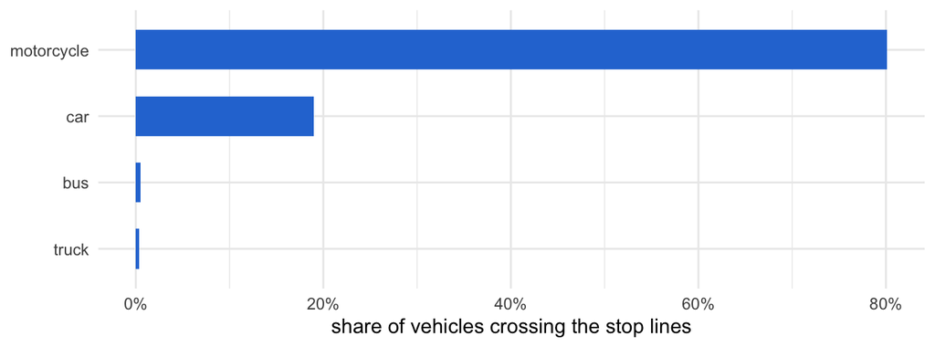

```r
mix <- lp %>% filter(kind == "stopline_loop") %>%
  summarise(across(c(n_motorcycle, n_car, n_bus, n_truck), sum)) %>%
  pivot_longer(everything(), names_to = "class", values_to = "vehicles") %>%
  mutate(class = sub("n_", "", class), share = vehicles / sum(vehicles))
ggplot(mix, aes(reorder(class, share), share)) + geom_col(fill = "#2a78d6", width = 0.6) + coord_flip() +
  scale_y_continuous(labels = scales::percent) + labs(x = NULL, y = "share of vehicles crossing the stop lines")
```

## 2.2 Queues over one recorded hour

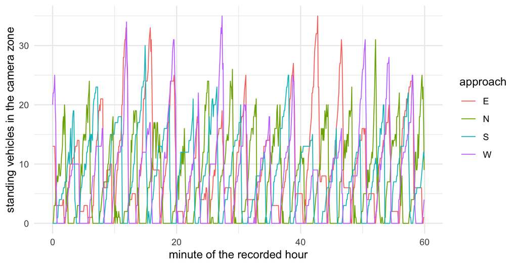

```r
one <- tk %>% filter(episode_id == min(episode_id)) %>%
  select(t, starts_with("q_veh_")) %>% select(-matches("_S1S2|_S2$")) %>%
  pivot_longer(-t, names_to = "approach", values_to = "standing") %>%
  mutate(approach = sub("q_veh_", "", approach), minute = (t - min(t)) / 60)
ggplot(one, aes(minute, standing, colour = approach)) + geom_line(linewidth = 0.4) +
  labs(x = "minute of the recorded hour", y = "standing vehicles in the camera zone", colour = "approach")
```

## 2.3 Stopped delay by controller

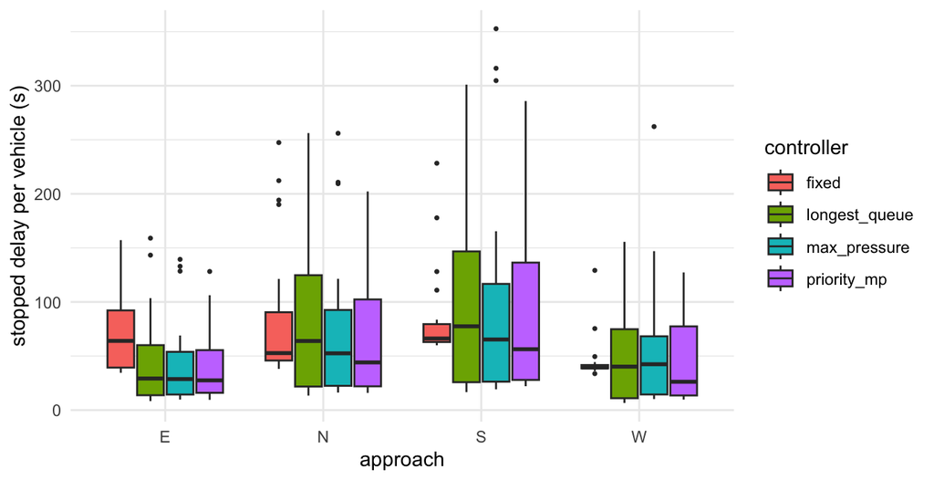

```r
ep %>% select(controller, starts_with("stopped_delay_s_")) %>%
  pivot_longer(-controller, names_to = "approach", values_to = "delay") %>%
  mutate(approach = sub("stopped_delay_s_", "", approach)) %>%
  ggplot(aes(approach, delay, fill = controller)) + geom_boxplot(outlier.size = 0.6) +
  labs(x = "approach", y = "stopped delay per vehicle (s)", fill = "controller")
```

## 2.4 Ambulance passages

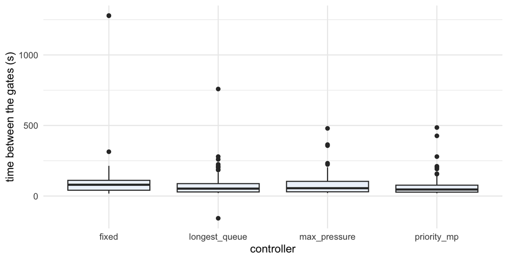

```r
amb %>% left_join(select(ep, episode_id, controller), by = "episode_id") %>%
  filter(!is.na(cordon_time_s)) %>%
  ggplot(aes(controller, cordon_time_s)) + geom_boxplot(fill = "#eef3fb") +
  labs(x = "controller", y = "time between the gates (s)")
```

# 3 A feasibility model

The controller in the project imitates a priority-aware rule. Its label, `y_teacher_stage`, is the stage the rule requests at each 5 s tick. A small decision tree is trained on the first two seeds and tested on the third, and compared with two baselines: keeping the current stage, and always guessing the most common stage.

```r
tk <- tk %>% left_join(select(ep, episode_id, seed), by = "episode_id") %>%
  filter(!is.na(y_teacher_stage)) %>% mutate(stage = factor(stage))
tk %>% count(y_teacher_stage) %>% mutate(share = round(n / sum(n), 3))
```

```
##   y_teacher_stage     n share
## 1              S1 23565 0.303
## 2              S2  8925 0.115
## 3              S3 28870 0.371
## 4              S4 16400 0.211
```

```r
if (length(unique(tk$seed)) >= 2) {            # the release: hold out the last seed
  is_test <- tk$seed == max(tk$seed)
} else {                                         # a one-seed pilot: hold out the last episode
  is_test <- tk$episode_id == max(tk$episode_id)
}
train <- tk[!is_test, ]
test  <- tk[is_test, ]
fit <- rpart(factor(y_teacher_stage) ~ stage_pressure_S1 + stage_pressure_S2 + stage_pressure_S3 +
               stage_pressure_S4 + stage + t_since_green_s + ev_N + ev_E + ev_S + ev_W,
             data = train, control = rpart.control(maxdepth = 5, minbucket = 20))
pred <- predict(fit, test, type = "class")
majority <- names(which.max(table(train$y_teacher_stage)))
acc <- data.frame(model = c("decision tree", "stillness", "majority"),
                  accuracy = c(mean(as.character(pred) == test$y_teacher_stage),
                               mean(as.character(test$stage) == test$y_teacher_stage),
                               mean(test$y_teacher_stage == majority)))
write.csv(acc, "demo_results.csv", row.names = FALSE)      # read by the report build
acc %>% mutate(model = c("decision tree", "stillness: keep the current stage", "majority stage"), accuracy = round(accuracy, 3))
```

```
##                               model accuracy
## 1                     decision tree    0.687
## 2 stillness: keep the current stage    0.308
## 3                    majority stage    0.373
```

```r
table(predicted = pred, true = test$y_teacher_stage)
```

```
##          true
## predicted   S1   S2   S3   S4
##        S1 6083 1078  909 1193
##        S2    0    0    0    0
##        S3 1280  946 8388 1315
##        S4  556  474  359 3339
```

```r
fit$frame %>% filter(var != "<leaf>") %>% head(6) %>% select(var, n)
```

```
##                 var     n
## 1 stage_pressure_S3 51840
## 2 stage_pressure_S4 16083
## 3 stage_pressure_S1  7529
## 4             stage  3952
## 5             stage  2125
## 6 stage_pressure_S1  8554
```

# 4 What the demonstration shows

The tables load as documented, every column the dictionary lists is present, and the junction’s traffic, queues and ambulance passages behave as the methodology describes. A shallow tree already learns much of the teacher’s rule from sensor columns alone, which makes the full model comparison in the report feasible.